# STageR

Alena van Bömmel

2023-05-26

## STageR

Prediction of the aging stage of mouse (early life, midlife, late life) based on DNA methylation in intestine.

Here, we show prediction for the validation data set from Olecka & van Bömmel et al. including the calculation of cluster centroids.

## Read the data

- cytosines with corresponding cluster (all 19 clusters included)
- cytosines with methylation values from the validation data set
- STageR (trained multionomial logistic regression)

Please note: Genomic positions are denoted in the column “co” as a string in the following format: “chr1:4491976”.

The validation data set was already intersected with the aDMR-cytosines, such that it contains ~ 70 000 positions.

```r
# cytosines with corresponding cluster (all 19 clusters inlcuded)
clusters <- readRDS("data/clusters.cytosines.rds")
# read methylation values of the validation data set
validation.data <- readRDS("data/validation.data.rds")
# read the STageR classifier
STageR.fit <- readRDS("data/STageR.glmnet.rds")
```

## Calculate centroid values per cluster

The calculation is made for all samples (columns) in the data frame with numeric entries. The whole data frame is transposed to have samples in rows and cluster centroids in columns.

The nonlinear clusters C2,C3 and C4 are then selected for prediction with STageR.

```r
gc.medians.clusters <- validation.data %>%
  left_join(clusters, by=c("co")) %>%
  dplyr::select(-co) %>%
  group_by(cluster) %>%
  dplyr::summarise_if(is.numeric, median, na.rm = TRUE) %>%
  pivot_longer(cols=c(-cluster),names_to="Samples") %>% # transpose the data frame
  pivot_wider(names_from=c(cluster)) %>%
  column_to_rownames("Samples")

gc.medians.clusters.selected <- gc.medians.clusters %>%
                                dplyr::select(C2, C3, C4)
```

## Predict the aging stage using STageR

```r
predicted.probs <- stats::predict(STageR.fit, newx=as.matrix(gc.medians.clusters.selected),
                            s=STageR.fit$lambda.min, type="response")
```

## Plot the prediction results

Plot the the barplot with predicted probabilities for each sample and show the predicted stage.

The true age of the validation samples is known and can be derived from the sample IDs.

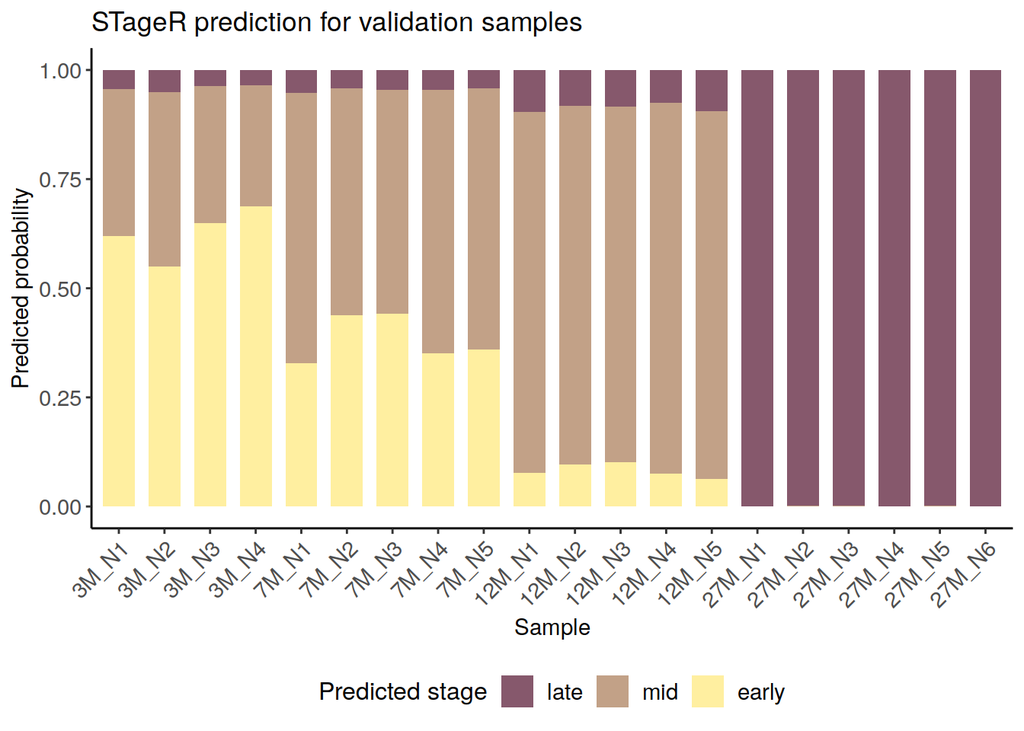

```r
pred.probs <- as.data.frame(predicted.probs[,,1]) %>%
  rownames_to_column("sample") %>%
  pivot_longer(cols = c(-sample),
               names_to = "stage",
               values_to = "prob") %>%
  dplyr::mutate(stage = factor(stage, levels = c("late","mid","early"))) %>%
  dplyr::mutate(age_true = gsub("X","",sample)) %>%
  dplyr::mutate(age_true = as.numeric(gsub("M_N[0-9]","",age_true))) %>%
  dplyr::mutate(sample = gsub("X","", sample))


ggplot(pred.probs, aes(x=reorder(sample, c(age_true)), y=prob, group=stage, fill=stage)) +
  geom_col(width= 0.7, alpha=0.7,
           position=position_stack(0.88)) +
  scale_fill_manual(values=pal.age.gr, name="Predicted stage")+
  scale_x_discrete(guide = guide_axis(n.dodge = 1, angle=45, check.overlap=F))+
  labs(title = "STageR prediction for validation samples") +
  xlab("Sample") +
  ylab("Predicted probability") +
  theme_classic() +
  theme(legend.position = "bottom",
        axis.text.y = element_text(size=11),
        axis.text.x = element_text(size=11),
        legend.title = element_text(size=12),
        legend.text = element_text(size=11))
```

```r
# numbers for the barplot
pred.probs.table <- pred.probs %>%
  mutate(prob = round(prob,3)) %>%
  dplyr::select(-age_true) %>%
  pivot_wider(names_from = stage,
              values_from = prob)

#
pred.summary <- pred.probs %>%
  group_by(sample) %>%
  top_n(1, prob) %>%
  mutate(stage= factor(stage, levels=c("early","mid","late")))
print(pred.summary)
```

```
## # A tibble: 20 × 4
## # Groups:   sample [20]
##    sample stage  prob age_true
##    <chr>  <fct> <dbl>    <dbl>
##  1 3M_N1  early 0.619        3
##  2 3M_N2  early 0.550        3
##  3 3M_N3  early 0.650        3
##  4 3M_N4  early 0.688        3
##  5 7M_N1  mid   0.619        7
##  6 7M_N2  mid   0.520        7
##  7 7M_N3  mid   0.513        7
##  8 7M_N4  mid   0.604        7
##  9 7M_N5  mid   0.598        7
## 10 12M_N1 mid   0.826       12
## 11 12M_N2 mid   0.821       12
## 12 12M_N3 mid   0.814       12
## 13 12M_N4 mid   0.850       12
## 14 12M_N5 mid   0.843       12
## 15 27M_N1 late  0.999       27
## 16 27M_N2 late  0.997       27
## 17 27M_N3 late  0.998       27
## 18 27M_N4 late  0.999       27
## 19 27M_N5 late  0.997       27
## 20 27M_N6 late  0.999       27
```

## Confusion matrix

Confusion matrix with percentage values and with absolute values.

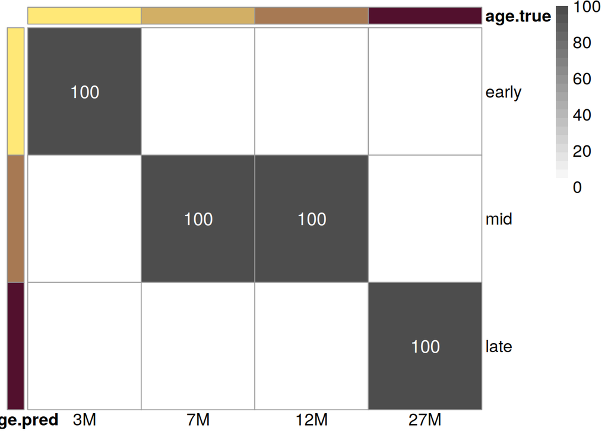

```r
abs.n <- pred.summary %>% group_by(age_true) %>% tally() # number of samples per age group

conf.mat <- pred.summary %>%
  group_by(age_true) %>% dplyr::count(stage) %>%
  left_join(abs.n, by="age_true", suffix = c("",".abs")) %>%
  mutate(perc = n/n.abs) %>%
  dplyr::select(-c(n, n.abs)) %>%
  pivot_wider(names_from = age_true,
              values_from = perc,
              values_fill = 0) %>%
  column_to_rownames("stage") %>%
  rename_with(~ paste0(.x, "M"))

age.orig <- data.frame(stage.pred = rownames(conf.mat))
rownames(age.orig) <- rownames(conf.mat)

age.new = data.frame(age.true = colnames(conf.mat))
rownames(age.new) <- colnames(conf.mat)

pal.age.new <- c('#ffe877', '#d2af65', '#a77953', '#52102d')
names(pal.age.new) <- colnames(conf.mat)

cluster.cols <- list(stage.pred=pal.age.gr, age.true=pal.age.new)

col.heatmap <- colorRampPalette(colors=c("white","grey30"))(21)

pheatmap::pheatmap(100*as.matrix(conf.mat),
                   show_rownames = T, show_colnames = T,
                   angle_col = "0", fontsize = 14,
                   cluster_cols = F, cluster_rows = F,
                   col = col.heatmap,
                   annotation_row = age.orig, annotation_col = age.new,
                   annotation_colors = cluster.cols, annotation_legend = F,
                   display_numbers = TRUE, number_format = "%.0f",
                   number_color = "white", fontsize_number = 15)
```

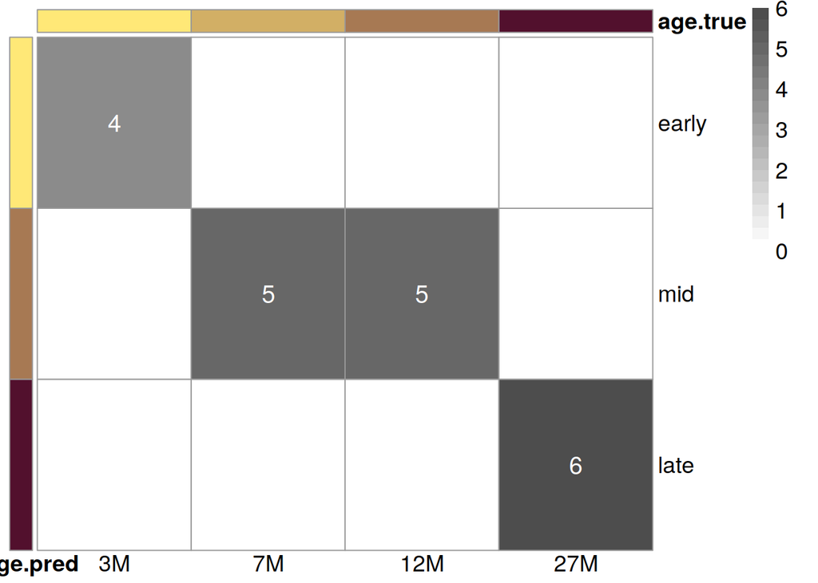

```r
conf.mat.abs <- pred.summary %>%
  group_by(age_true) %>% dplyr::count(stage) %>%
  pivot_wider(names_from = age_true,
              values_from = n,
              values_fill = 0) %>%
  column_to_rownames("stage") %>%
  rename_with(~ paste0(.x, "M"))

pheatmap::pheatmap(as.matrix(conf.mat.abs),
                   show_rownames = T, show_colnames = T,
                   angle_col = "0", fontsize = 14,
                   cluster_cols = F, cluster_rows = F,
                   col = col.heatmap,
                   annotation_row = age.orig, annotation_col = age.new,
                   annotation_colors = cluster.cols, annotation_legend = F,
                   display_numbers = TRUE, number_format = "%.0f",
                   number_color = "white", fontsize_number = 15)
```